# FiveThirtyEight

- Show All Code
- Hide All Code
- View Source

Author

Meshack Amadi

Published

January 24, 2025

# Summary of the Gun Deaths Data

This article explores the more than 33,000 annual gun deaths in the U.S. and provides the causes of this gun deaths, including suicides, homicides, accidental shootings, and mass shootings, using data primarily from the Center for Disease Control’s Multiple Cause of Death database. The analysis covers averages from 2012 to 2014 and incorporates additional sources for categories like police shootings, mass shootings, and terrorism-related gun deaths. It provides a detailed breakdown of firearm fatalities by age, intent, and demographic groups, relying on standardized methodologies and third-party estimates to ensure accuracy. The project aims to shed light on the scope of gun violence and the factors contributing to these deaths.

```r
library(dplyr)
library(ggplot2)
library(tidyr)
library(readr)
library(scales)
```

```r
csv_file <- "C:/Users/AMADI/Downloads/full_data.csv"
data538 <- read_csv(csv_file)
```

```r
#taking a quick look of the dataset
head(data538)
```

```
# A tibble: 6 × 11
   ...1  year month intent  police sex     age race     hispanic place education
  <dbl> <dbl> <chr> <chr>    <dbl> <chr> <dbl> <chr>       <dbl> <chr> <chr>
1     1  2012 01    Suicide      0 M        34 Asian/P…      100 Home  BA+
2     2  2012 01    Suicide      0 F        21 White         100 Stre… Some col…
3     3  2012 01    Suicide      0 M        60 White         100 Othe… BA+
4     4  2012 02    Suicide      0 M        64 White         100 Home  BA+
5     5  2012 02    Suicide      0 M        31 White         100 Othe… HS/GED
6     6  2012 02    Suicide      0 M        17 Native …      100 Home  Less tha…
```

```r
glimpse(data538)
```

```
Rows: 100,798
Columns: 11
$ ...1      <dbl> 1, 2, 3, 4, 5, 6, 7, 8, 9, 10, 11, 12, 13, 14, 15, 16, 17, 1…
$ year      <dbl> 2012, 2012, 2012, 2012, 2012, 2012, 2012, 2012, 2012, 2012, …
$ month     <chr> "01", "01", "01", "02", "02", "02", "02", "03", "02", "02", …
$ intent    <chr> "Suicide", "Suicide", "Suicide", "Suicide", "Suicide", "Suic…
$ police    <dbl> 0, 0, 0, 0, 0, 0, 0, 0, 0, 0, 0, 0, 0, 0, 0, 0, 0, 0, 0, 0, …
$ sex       <chr> "M", "F", "M", "M", "M", "M", "M", "M", "M", "M", "M", "M", …
$ age       <dbl> 34, 21, 60, 64, 31, 17, 48, 41, 50, NA, 30, 21, 43, 34, 27, …
$ race      <chr> "Asian/Pacific Islander", "White", "White", "White", "White"…
$ hispanic  <dbl> 100, 100, 100, 100, 100, 100, 100, 100, 100, 998, 100, 100, …
$ place     <chr> "Home", "Street", "Other specified", "Home", "Other specifie…
$ education <chr> "BA+", "Some college", "BA+", "BA+", "HS/GED", "Less than HS…
```

```r
View(data538)
```

# Analysis

This boxplot provides similar insights to the visualization in the fivethirtyEight article. It shows the Gun Deaths by Intent and the age of the perpetrators, grouped by race

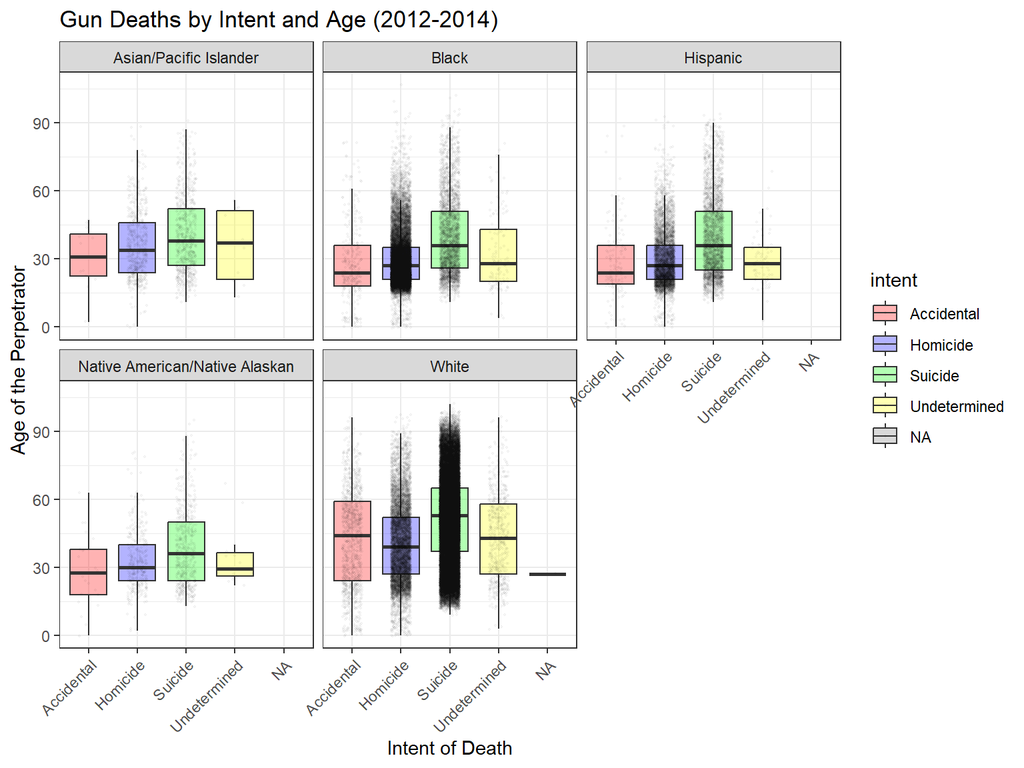

```r
ggplot(data538, aes(x = intent, y = age, fill = intent)) +
  geom_boxplot(outlier.shape = NA, alpha = 0.3) +
  geom_jitter(width = 0.2, alpha = 0.03, size = 0.3, color = "black") +
  scale_fill_manual(values = c(
    "Accidental" = "red",
    "Homicide" = "blue",
    "Suicide" = "green",
    "Undetermined" = "yellow"
  )) +
  theme_bw() +
  labs(
    title = "Gun Deaths by Intent and Age (2012-2014)",
    x = "Intent of Death",
    y = "Age of the Perpetrator"
  ) +
  theme(axis.text.x = element_text(angle = 45, hjust = 1)) +
  facet_wrap(~ race)
```